# Exploratory Data Analysis on Red Wine Quality Dataset

#### Then to further understand the correlation between the four variables of alcohol,citric acid,sulphates and volatile acidity, I created density plots to compare with the boxplots.

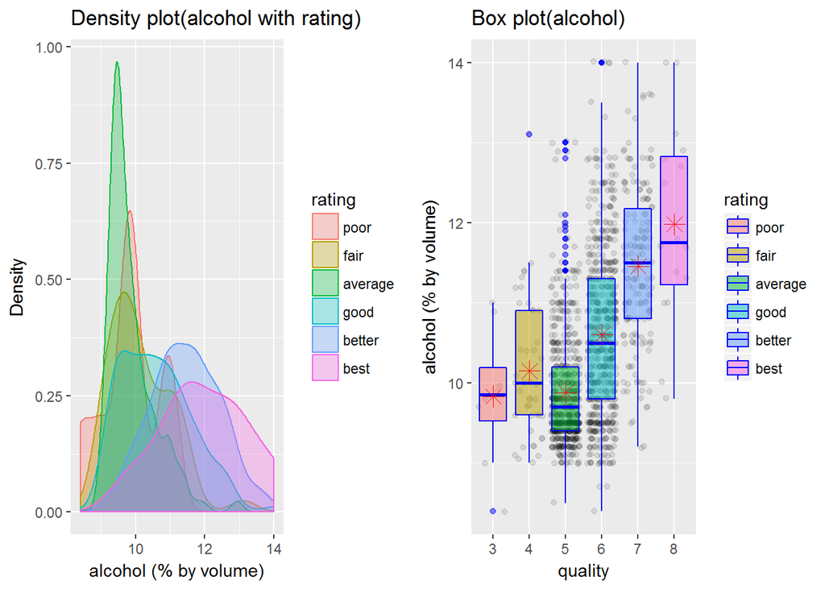

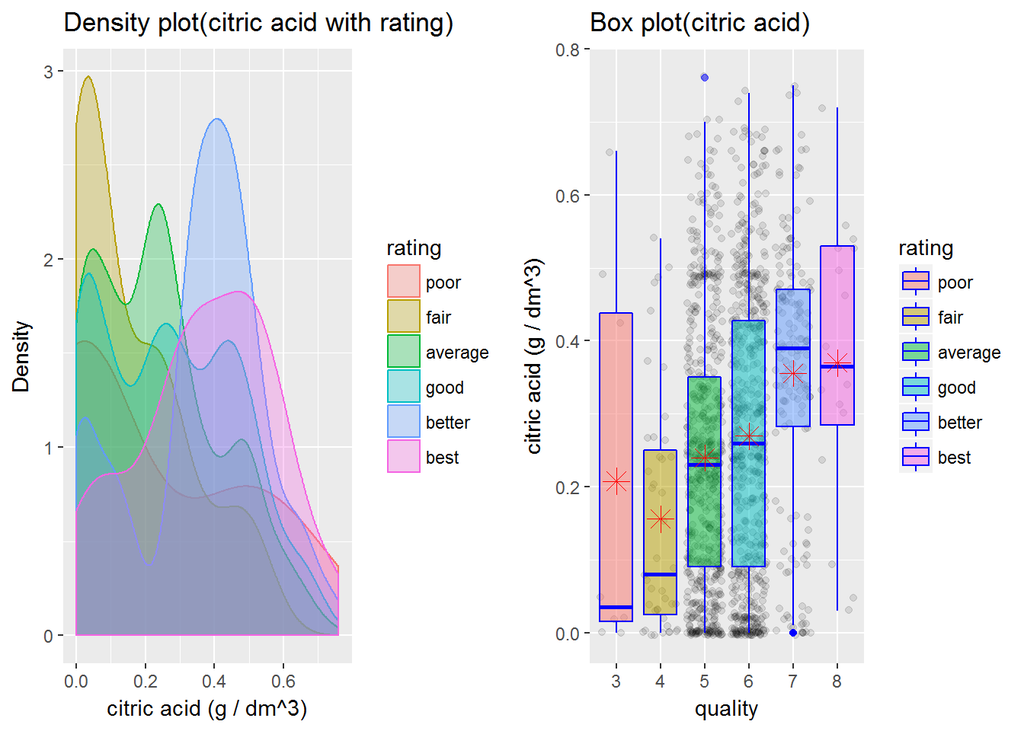

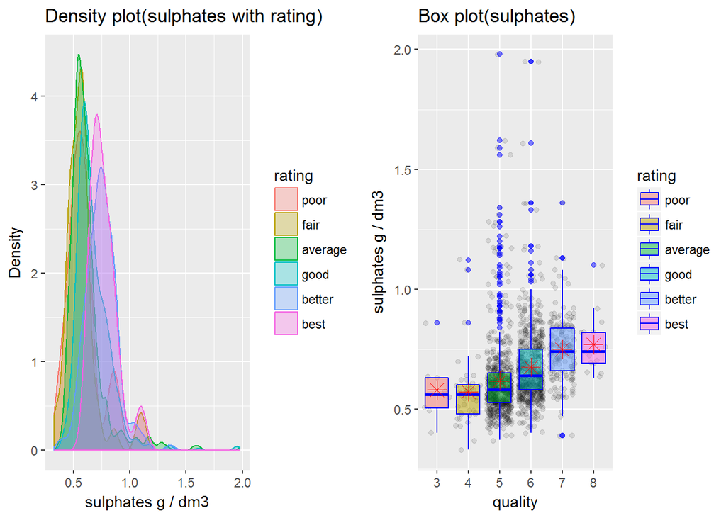

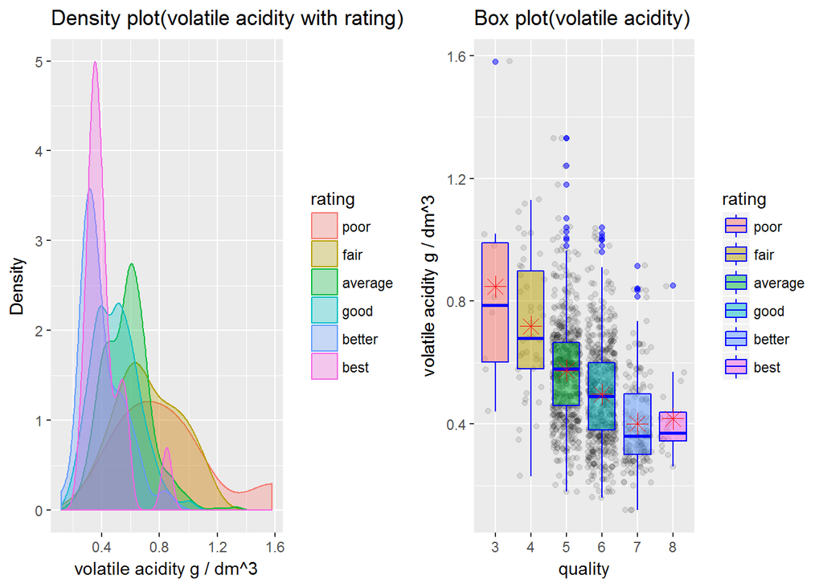

#### These plots confirm that for variable volatile acidity, the quality increases as the value decreases and for the other three variables, quality increases as the values increases.

# Bivariate Analysis

### Talk about some of the relationships you observed in this part of the investigation. How did the feature(s) of interest vary with other features in the dataset?

#### * There seem to be no effect on quality by variables fixed acidity,residual sugar and chlorides.

#### * Lower values for volatile acidity variable seem to produce better quality of wine.

#### * Higher values for citric acid, sulphates and alcohol seem to produce better quality of wine.

#### * total sulfur dioxide and free sulfur dioxide seem to be higher only in average quality wines.

### Did you observe any interesting relationships between the other features (not the main feature(s) of interest)?

#### * From the correlation plot, I found that there is positive correlation of 0.67 between free sulfur dioxide and total sulfur dioxide variables, density and fixed acidity variables, citric acid and fixed acidity variables and a negative correlation of -0.68 between ph and fixed acidity variables. These variables except for citric acid had a very low correlation with quality variable.

#### * Out of all the independent variables, dependent variable quality had the highest correlation of 0.48 with variable alcohol.

### What was the strongest relationship you found?

#### The strongest correlation was between variables ph and fixed acidity with a value of -0.68.

# Multivariate Plots Section

#### Since the four variables alcohol,sulphates,citric acid and volatile acidity had a correlation with quality, I wanted to find if a combination of these variables affected the quality variable. All the other variables were dropped from further consideration. I created scatter plots to visualize the correlation among these variables.

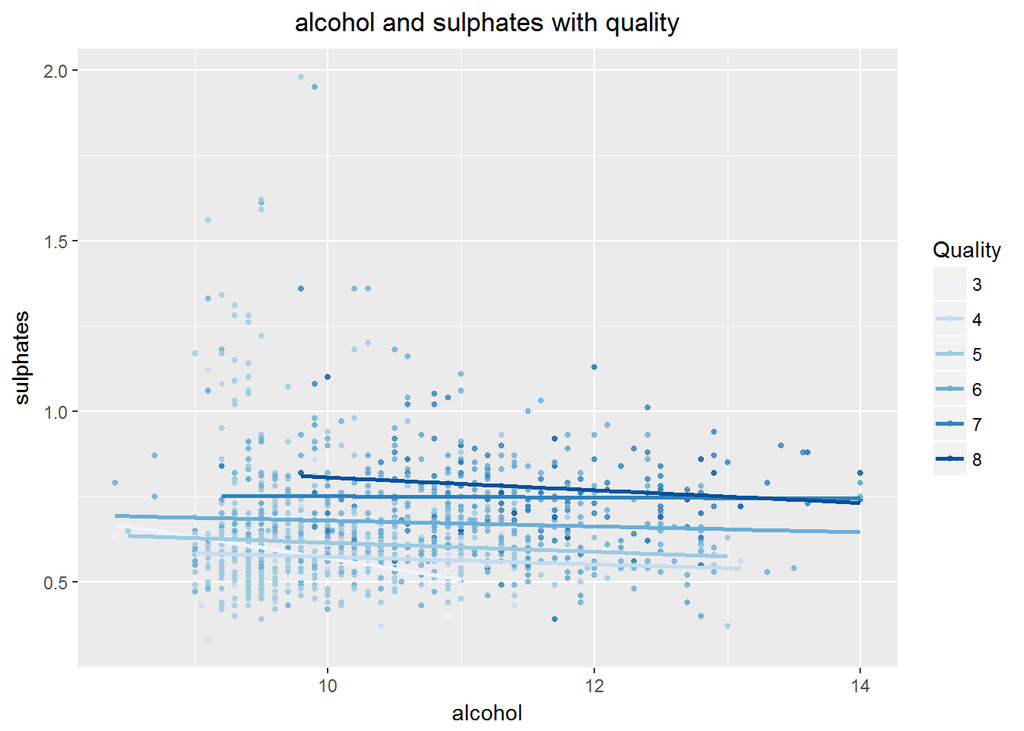

#### This plot shows that higher value of sulphates and alcohol produced higher quality wines.

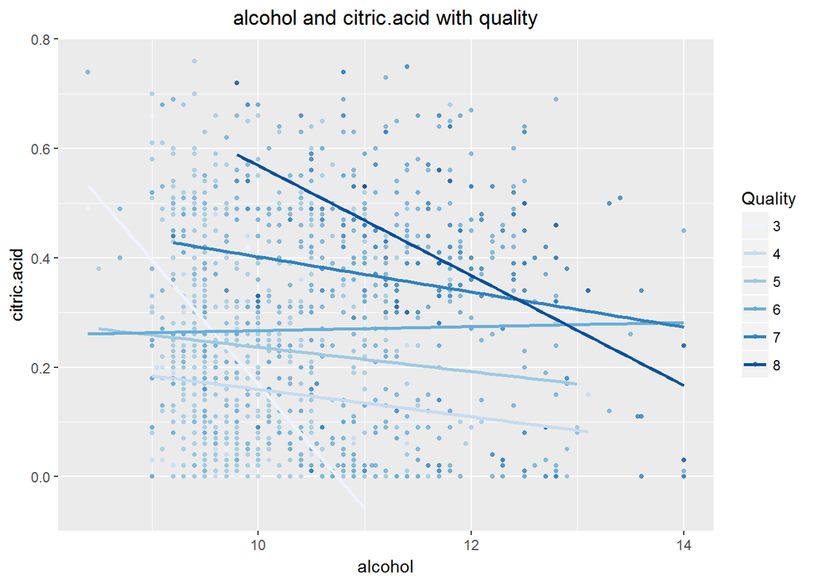

#### This plot shows that higher value of citric acid and alcohol produced higher quality wines.

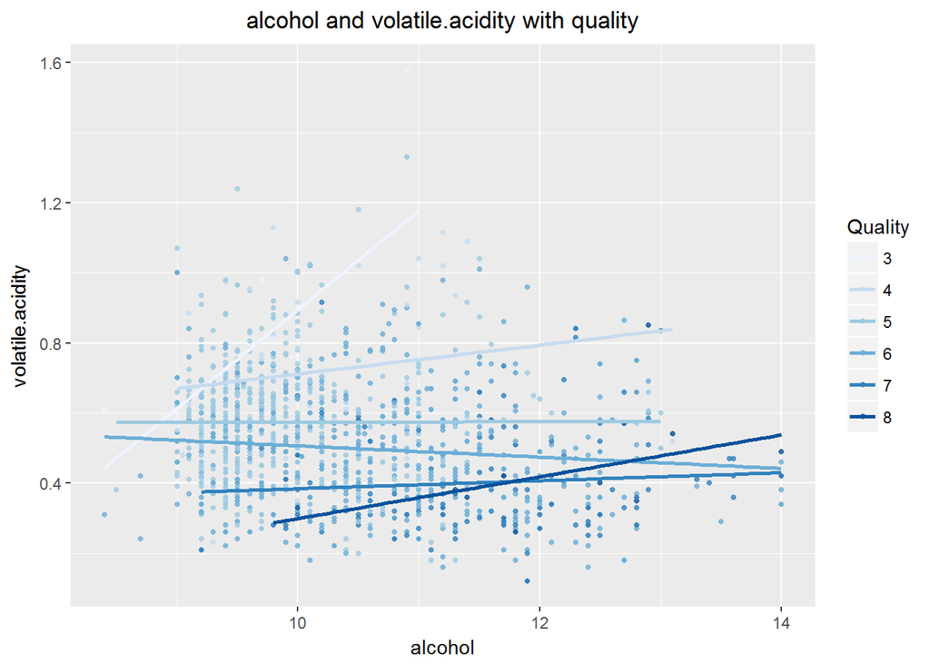

#### This plot shows that higher value of alchohol and lower values of volatile acidity produced higher quality wines.

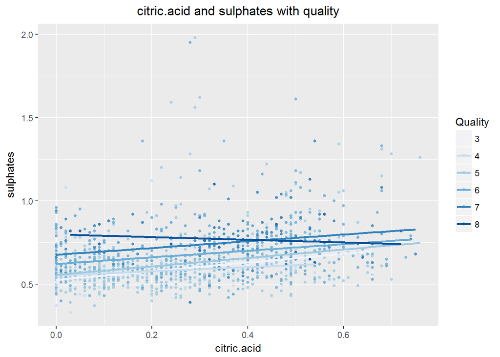

#### This plot shows that higher value of sulphates and citric acid produced higher quality wines.

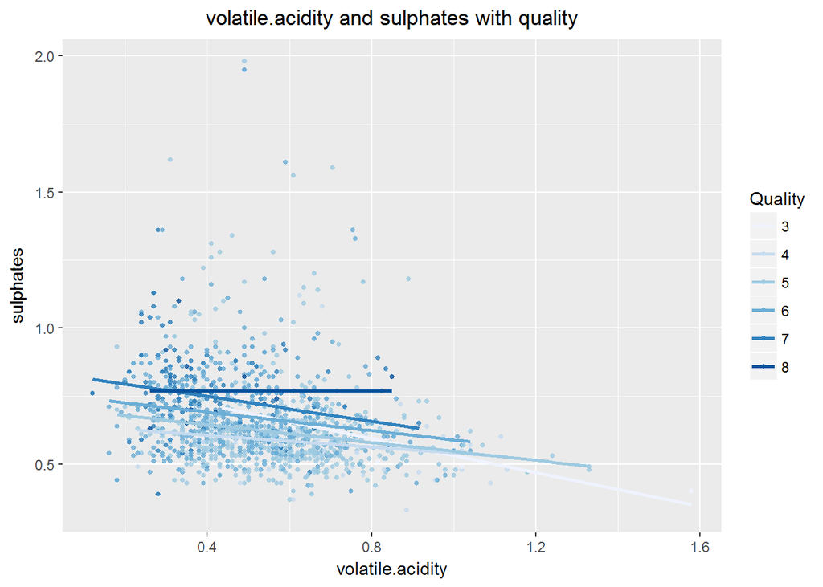

#### This plot shows that higher value of sulphates and lower values of volatile acidity produced higher quality wines.

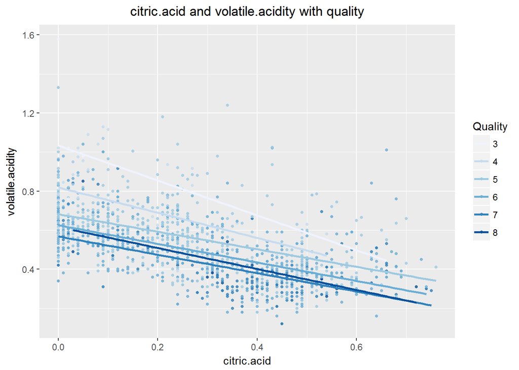

#### This plot shows that lower values of volatile acidity and higher values of citric acid produced higher quality wines.

# Multivariate Analysis

### Talk about some of the relationships you observed in this part of the investigation. Were there features that strengthened each other in terms of looking at your feature(s) of interest?

#### In this part of the investigation after analyzing the 6 plots above, I confirmed that low values of volatile acidity, and high values of alcohol,citric acid and sulphates produced higher quality wines.

### Were there any interesting or surprising interactions between features?

#### An interesting finding was that variables ph, fixed acidity and density did not seem to have an effect on the quality variable. Neither did the variables residual sugar,chlorides,free sulfur dioxide and total sulfur dioxide have an effect on the quality.

### OPTIONAL: Did you create any models with your dataset? Discuss the strengths and limitations of your model.

```
##
## Calls:
## m1: lm(formula = quality ~ alcohol, data = wine_df)
## m2: lm(formula = quality ~ alcohol + citric.acid, data = wine_df)
## m3: lm(formula = quality ~ alcohol + citric.acid + sulphates, data = wine_df)
## m4: lm(formula = quality ~ alcohol + citric.acid + sulphates + volatile.acidity,
##     data = wine_df)
##
## ================================================================
##                        m1         m2         m3         m4
## ----------------------------------------------------------------
##   (Intercept)        1.788***   1.665***   1.254***   2.453***
##                     (0.183)    (0.180)    (0.183)    (0.212)
##   alcohol            0.370***   0.363***   0.351***   0.319***
##                     (0.018)    (0.017)    (0.017)    (0.017)
##   citric.acid                   0.747***   0.517***  -0.079
##                                (0.094)    (0.096)    (0.109)
##   sulphates                                0.912***   0.797***
##                                           (0.110)    (0.106)
##   volatile.acidity                                   -1.204***
##                                                      (0.117)
## ----------------------------------------------------------------
##   R-squared              0.2        0.3        0.3        0.4
##   adj. R-squared         0.2        0.3        0.3        0.4
##   sigma                  0.7        0.7        0.7        0.6
##   F                    444.5      263.4      207.1      193.1
##   p                      0.0        0.0        0.0        0.0
##   Log-likelihood     -1496.3    -1465.4    -1431.5    -1380.4
##   Deviance             680.3      651.5      621.2      578.3
##   AIC                 2998.6     2938.7     2872.9     2772.8
##   BIC                 3014.4     2959.8     2899.3     2804.4
##   N                   1427       1427       1427       1427
## ================================================================
```

# Final Plots and Summary

### Plot One

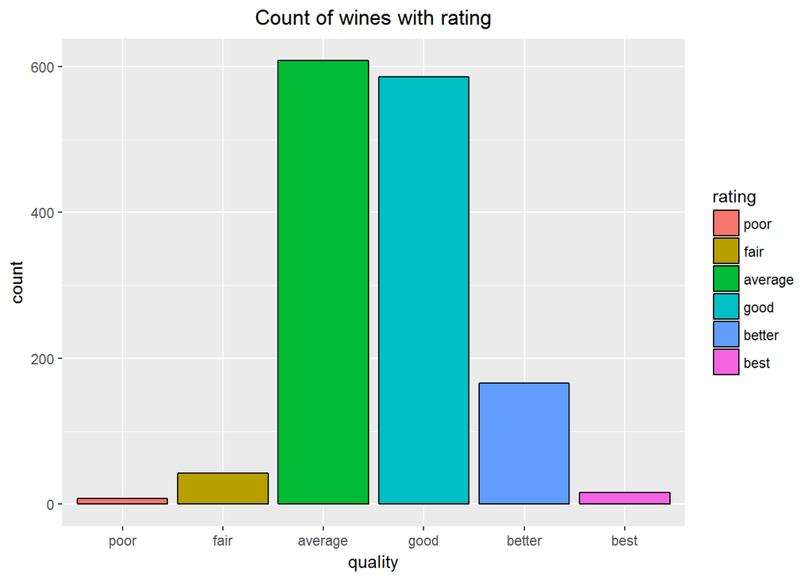

### Plot Two

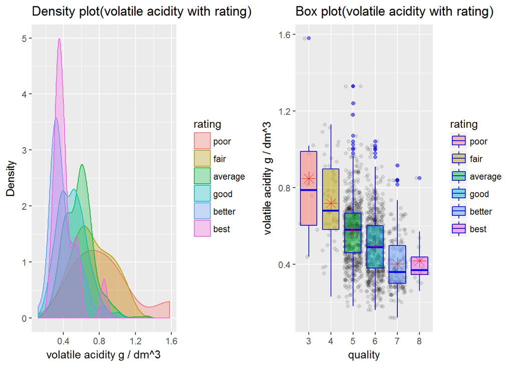

### Description Two

#### The above two plots show the negative correlation (-0.39) of variable volatile acidity and variable quality of the dataset. The density plot shows that quality of the wine increases as volatile acidity decreases. The same information is shown in the boxplot.

### Plot Three

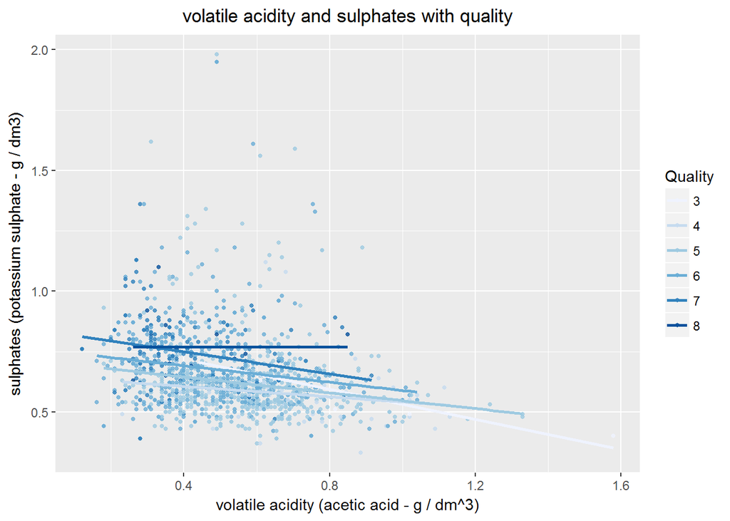

### Description Three

#### This scatter plot shows the relation between three of the variables of the dataset namely volatile acidity, sulphates and quality. It shows that lower values of volatile acidity and higher values of sulphates produced higher quality wines.

# Reflection

#### The purpose of this data exploration was to identify the variables that influences the quality of red wines. I started out by finding the distribution of each variable using histograms and checking the outliers using boxplots. For three of the variables, namely citric acid, residual sugar and free sulfur dioxide, the outliers were removed from the dataset.

#### I then wanted to find the correlation between the variables and used the cor function which printed out a list of correlation values of each variable with the quality variable. I decided to use the correlation plot which displays the correlation value of every variable with each other. From the correlation plot, I looked at the variables that had the highest correlation with the quality variable. Density plots and boxplots helped me narrow the number of variables that influenced the quality of wine.

#### The scatter plots with three variables helped me conclude that variables alcohol,sulphates,citric acid and volatile acidity were the four variables that had the most influence in determining the quality of the wine.

#### The most surprising aspect was that out of 11 variables, only four were related to quality.

#### With over 12 variables, it was difficult to narrow down which variables were related to quality. Every single variable was checked using different plots. Deciding which plots to use was time-consuming. Once I tried out the different plots, it became obvious which ones to use. Initially, I used cor function to print out the correlation values which was difficult to analyze fast. The correlation plot made it much easier.

#### Having a larger dataset with more variables and having more than 3 evaluations by experts could produce a more accurate analysis of the wine quality. Future work could involve building machine learning models to predict accuracy.

# References

#### * [outliercheck](https://www.r-bloggers.com/identify-describe-plot-and-remove-the-outliers-from-the-dataset/)